# Treatment-Specific Variants Near ERG Genes

This report summarizes the analysis of treatment-specific variants found near ergosterol pathway genes, focusing on the hierarchical conservation pattern observed in these essential genes.

### Key Finding: Hierarchical Conservation Pattern

The analysis reveals a clear hierarchical conservation pattern around ERG genes:

- **Core Zone (0bp)**: No variants within ERG genes (0 variants)
- **Buffer Zone (0-1000bp)**: 0 variants in immediate regulatory regions
- **Intermediate Zone (1000-10000bp)**: 18 variants
- **Satellite Zone (10000-50000bp)**: 27 variants

This pattern strongly supports the biological model of purifying selection protecting essential gene functions, with only 1 variant found within 5kb of ERG genes (specifically 1 variant near ERG11).

## Overview Statistics

Total treatment-specific variants within 50kb of ERG genes: 45

Distribution by treatment:

- **WT-37**: 18 variants (40.0%)
- **CAS**: 15 variants (33.3%)
- **STC**: 8 variants (17.8%)
- **WTA**: 4 variants (8.9%)

## Distance Distribution

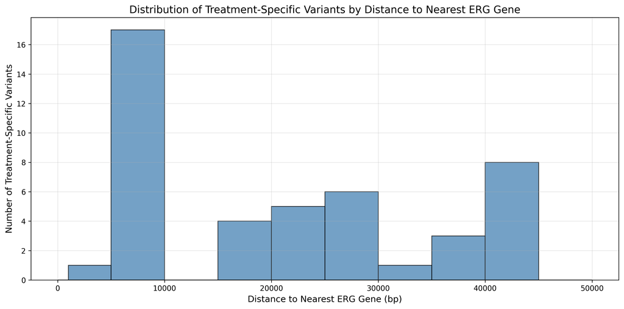

Figure 1: Distribution of treatment-specific variants by distance to nearest ERG gene.

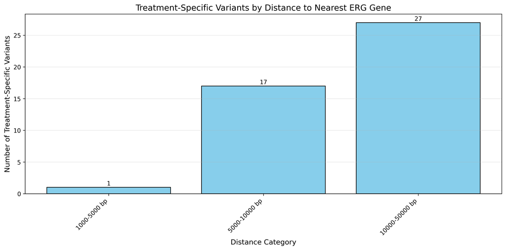

Figure 2: Number of treatment-specific variants in each distance category.

## Treatment Patterns

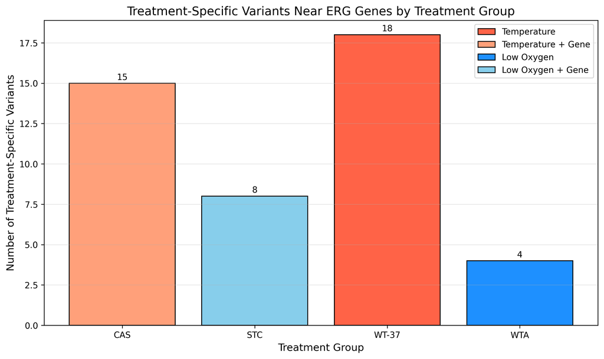

Figure 3: Distribution of treatment-specific variants by treatment group.

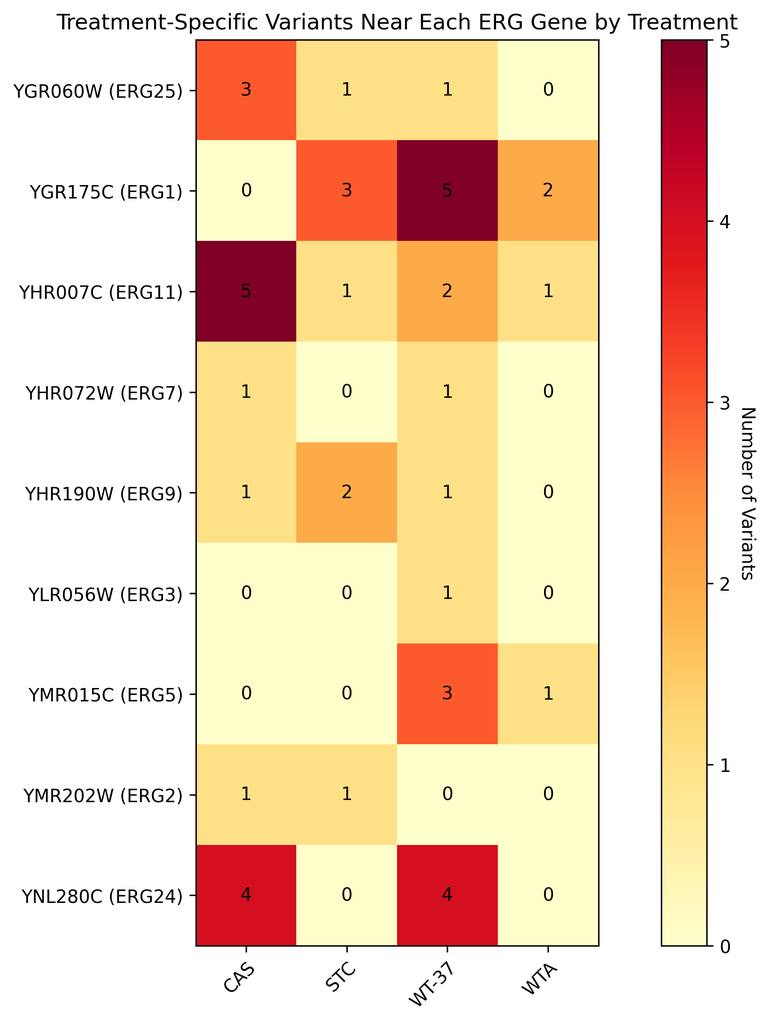

Figure 4: Heatmap showing the distribution of variants by ERG gene and treatment.

## Variant Effects and Impacts

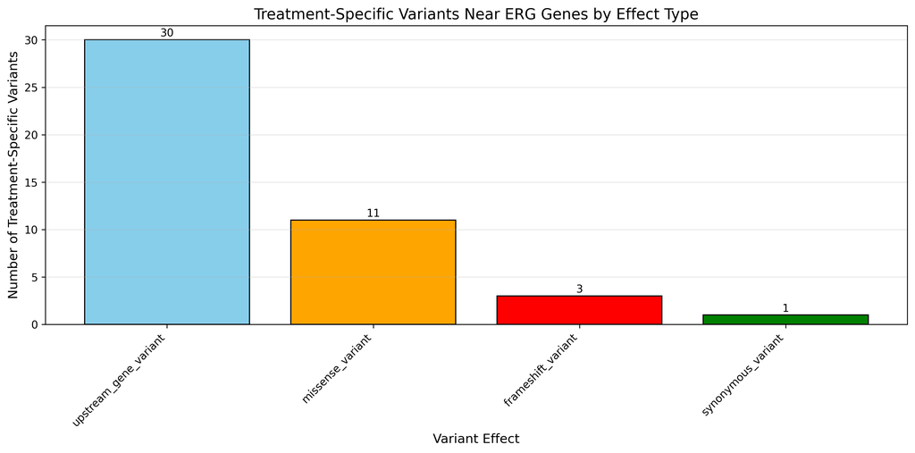

Figure 5: Distribution of treatment-specific variants by effect type.

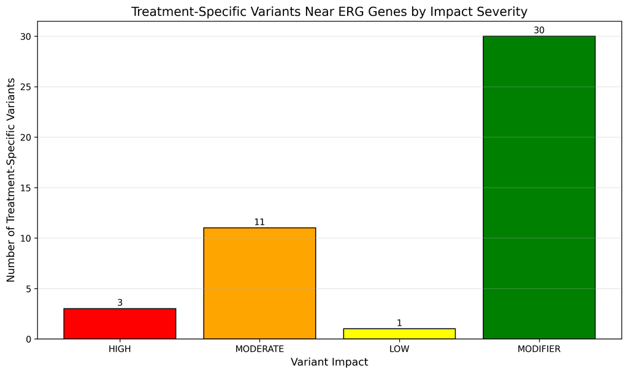

Figure 6: Distribution of treatment-specific variants by impact severity.